# BrainMap App

Author

Isaac Medeiros; João Cavalcante; Diego Coelho

[figure not shown]

This analysis was performed by [MCB Lab](https://mcblab.github.io/).

## Introdução

A seguinte aplicação tem como objetivo a vizualização nas variações dos níveis de expressão de genes no decorrer do desenvolvimento do cortex em Humanos. Em suma a ferramenta utiliza o conjunto de dados do BrainSpan Atlas of the Developing Human Brain e oferece uma interface espacial, utilizando o pacote ggseg, para mapear os níveis de expressão no atlas Desikan-Killiany (DK).

## Plotagem Teste

A vizualização obtida a seguir se baseia na utilização de dados provindos do MSigDB - https://www.gsea-msigdb.org/gsea/msigdb/human/collections.jsp#H - dando um suporte teórico afim de observar se os níveis de expressão batem com oque está sendo mostrado nos calculos de score compostos dos conjuntos de genes utilizados a seguir,

### GSVA Plot

A via escolhida para vizualização teste, com base no método de variação da atividade de vias biológicas, foi o “GOBP_FOREBRAIN_GENERATION_OF_NEURONS”. Está via documentada pelo Geno Ontology do MSingDB representa da geração de neuronios prosenséfalo.

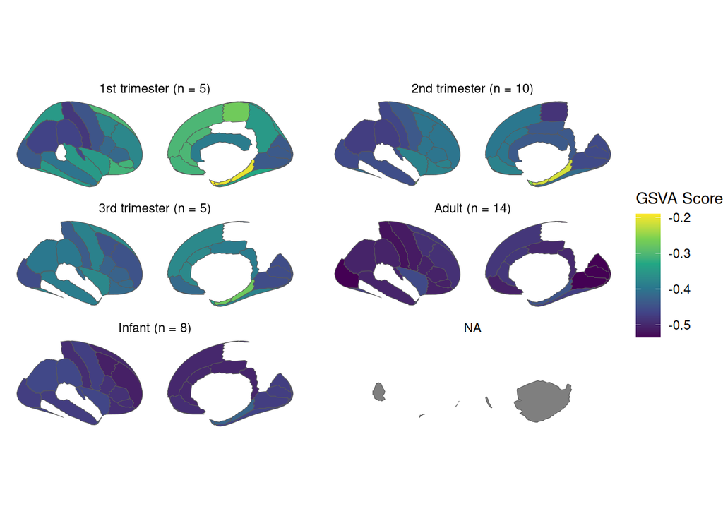

### ssGSEA

Métodologia de calculo alternativa do GSVA, ambos os métodos fazem o calculo de score composto para os conjuntos de genes de entrada. O método será escolhido medianta a eficiência de execução.

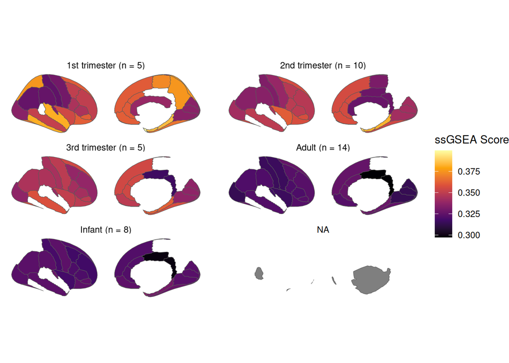

## Allen

Retirado do www.brainspan.org, os dados de scRNA-seq utilizados para a seguinte vizualização foram retirados de tercido Humano em um intervalo temporal que cobriu quase toda a extensão da vida humana, com amostras variando desde as 5 semanas pós-concepcionais (PCW) até os 64 anos de idade pós-natal.

### GSVA plot

Com base em Mingfeng et al., estamos observando um módulo obtido a partir do WGCNA, o ME37, onde foi observado que este módulo no decorrer do desenvolvimento apresenta sua maior taxa de mudança (flutuação de expressão) no neocórtex durante a transição do período fetal. Tentaremos observar como a ferramenta BrainMap poderá representar isso,

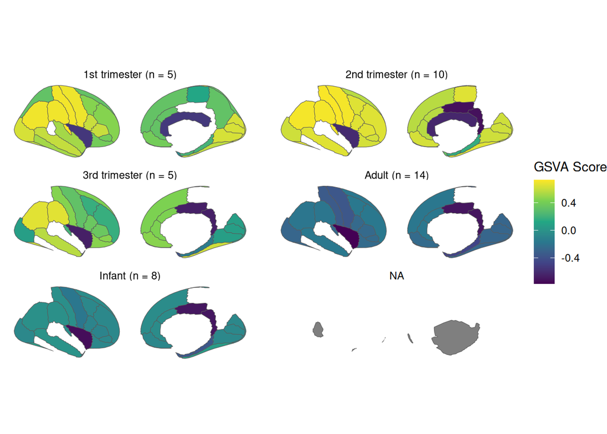

### ssGSEA

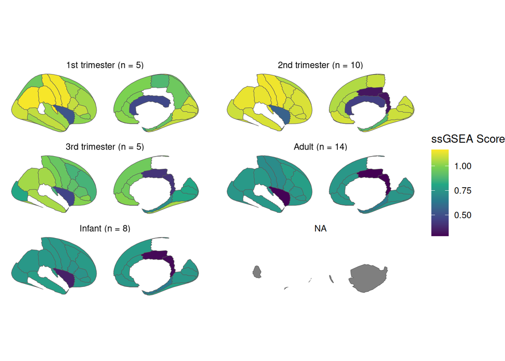